# Altmetric Authors

2018-07-27

A dataset of all the Authors that have ever Mentioned any of the Articles in the set. **Note:** this is Altmetric’s definition of the word Author, which means: someone who Mentioned an Article somewhere (they may also use the term ‘poster’ of a ‘post’ too, but they’re called Authors in the JSON from the API). This definition is distinct from the more academic definition, i.e.: ‘author of the article itself’: the [Dimensions](https://app.dimensions.ai/discover/publication) database might be a better source for finding out more about that type of author.

Join Authors onto the Mentions dataset and you can see which authors discussed the set the most:

```r
arrange(
  summarise(
      group_by(
        filter(
          mentions_with_authors,
          !is.na(author_name)),
        author_name),
    total_mentions = n(),
  ),
  desc(total_mentions)
)
```

```
# A tibble: 9,653 x 2
   author_name      total_mentions
   <chr>                     <int>
 1 Gill Livingston              52
 2 HIV Insight                  27
 3 Yahoo! News                  26
 4 Health Medicinet             25
 5 ToOur Shores                 22
 6 emocha                       20
 7 Health Affairs               20
 8 RinGs                        20
 9 Health Literacy              19
10 IFS                          19
# ... with 9,643 more rows
```

Join authors onto Mentions and the master Articles file and you can query how many times the Authors Mentioned a specific journal:

```r
arrange(
  summarise(
    group_by(
      filter(articles_with_mentions_and_authors,
             journal_title == "Journal of Cancer Policy",
             !is.na(author_name)),
      author_name
    ),
    total_mentions = n()
  ),
  desc(total_mentions)
)
```

```
# A tibble: 97 x 2
   author_name              total_mentions
   <chr>                             <int>
 1 Health Medicinet                      4
 2 MedicalXpress                         4
 3 health enews                          2
 4 New York Post                         2
 5 Stat News                             2
 6 815wrldtrvlr                          1
 7 About Kidneys                         1
 8 Alexis Dix                            1
 9 Alok Khorana                          1
10 "Ambrosio \"AJ\" Perera"              1
# ... with 87 more rows
```

## How authors are managed

The authors dataset is generated by the Altmetric Client using logic based upon how Altmetric themselves handle data about authors. Unsurprisingly, this logic varies according to the source of the Mention the author wrote. For instance, Twitter Authors are uniquely identified using the ’author_id_on_source’field, while blogging Authors are identified using the blog’s web address in the author_url field.

The Altmetric Client therefore parses each Mention, and then uses the source of the Mention to decide which field uniquely identifies the Author, using rules in the [AuthorManager Python class](https://github.com/CamLib/AltmetricClient/blob/master/altmetric_client/author_manager.py). Authors are then added to the Authors dataset with an id, generated by the Altmetric Client, that is unique to the dataset overall. This unique id is then posted back into the Mentions set, enabling Mentions to be joined back to their Authors. This in turn enables Authors that have posted multiple Mentions to be recorded more easily; essentially all of Altmetric’s logic regarding ‘which field identifies an Author for a given source’ is handled as simply as possible in the AuthorManager. Hence this logic doesn’t have to be added to the R used to analyse the dataset.

There is, however, no way of identifying the same author mentioning an Article across various sources (e.g. a journalist mentioning an Article in a news story, and then tweeting about it). This is pretty much par for the course with social media data, though, of course - there are plenty of people on platforms such as Twitter who aren’t who they say they are, so you can never really be *sure* if the id from one platform corresponds to the id from another.

## Authors Data Dictionary

The Author’s dataset contains the following fields:

### author_description

**Data type: character**

The author_description field is the description the Author has provided about themselves. In the test dataset at least, these only seem to be provided when the source is twitter or blogs.

```r
select(
  filter(authors,
         !is.na(author_description)),
  author_name,
  author_source,
  author_description
)
```

```
# A tibble: 8,018 x 3
   author_name      author_source author_description
   <chr>            <chr>         <chr>
 1 jesus alfaro     twitter       Catedrático de Derecho Mercantil.
 2 Rolf Groeneveld  twitter       Natural resource economist Wageningen University…
 3 Milan Vaishnav   twitter       @CarnegieEndow Sr Fellow + Director, @CarnegieSA…
 4 Nasra Roy        twitter       Crazy interest in food & cooking, intrigued by p…
 5 Research Ethics… twitter       #economicphilosophy, #researchethics, #researchi…
 6 Stefan Thewissen twitter       Research fellow @ODIdev, interested in inclusive…
 7 Michal Brzezins… twitter       economist @EconUW; research on inequality, pover…
 8 Max Roser        twitter       Researcher @UniOfOxford – Follow me for data vis…
 9 PG Kroeger       twitter       historicus, meedenker, penvoerder, dagvoorzitter…
10 Eric D. Munoz    twitter       Educator, political historian, and human. Podcas…
# ... with 8,008 more rows
```

These descriptions might actually provide a decent set of free text for Natural Language Processing, however. (My PhD research indicates that ‘Twitter Biography’ data potentially contains more useful information than tweets).

### author_follower_count

**Data type: int**

Altmetric record the number of followers each Author has, but only from Twitter and Reddit. This clearly has some potential for assessing the reach of a specific article or journal on either of those platforms (see **Notebook_Mentions.Rmd** for the code to do that).

```r
summarise(
  group_by(
    authors,
    author_source
  ),
  total_of_all_followers = sum(author_follower_count)
)
```

```
# A tibble: 9 x 2
  author_source total_of_all_followers
  <chr>                          <int>
1 blogs                              0
2 facebook                           0
3 googleplus                         0
4 news                               0
5 policy                             0
6 reddit                      18481686
7 twitter                     30453697
8 video                              0
9 wikipedia                          0
```

### author_id

**Data type: character**

An id generated by the Altmetric Client itself, which is unique to each analytical dataset, and is used to join each Author to the mentions they have written. The author_id is unique by author **and source** - the same actual Author cannot be identified across multiple sources. (See *How authors are managed* above).

### author_id_on_source

**Data type: character**

The information Altmetric have retrieved about the Author’s id *on the platform from which their Mentions have been found*. For instance, my Twitter author_id_on_source (for my largely unused Twitter account) would be EpiphanyLboro. This is the most-commonly-used unique identifier for Authors in sources, but isn’t the only field that can be used as an id. Some sources - e.g. blogs or pages about specific journalists in newspapers - potentially don’t have a specific Author id.

### author_image_url

**Data type: character**

This is a very odd field that mostly seems to take data from Altmetric’s own Amazon cloud web service. However, it does seem to uniquely identify policy ‘Authors’ - indeed the code chunk below:

```r
arrange(
  summarise(
    group_by(
      filter(mentions_with_authors, source == "policy"),
      author_image_url
    ),
    total = n()
  ),
  desc(total)
)
```

```
# A tibble: 393 x 2
   author_image_url                                                           total
   <chr>                                                                      <int>
 1 https://s3.amazonaws.com/cache.altmetric.com/policy/thumbnails/thumbnail-…    11
 2 https://s3.amazonaws.com/cache.altmetric.com/policy/thumbnails/thumbnail-…     9
 3 https://s3.amazonaws.com/cache.altmetric.com/policy/thumbnails/thumbnail-…     7
 4 https://s3.amazonaws.com/cache.altmetric.com/policy/thumbnails/thumbnail-…     6
 5 https://s3.amazonaws.com/cache.altmetric.com/policy/thumbnails/thumbnail-…     6
 6 https://s3.amazonaws.com/cache.altmetric.com/policy/thumbnails/thumbnail-…     3
 7 https://s3.amazonaws.com/cache.altmetric.com/policy/thumbnails/thumbnail-…     3
 8 https://s3.amazonaws.com/cache.altmetric.com/policy/thumbnails/thumbnail-…     3
 9 https://s3.amazonaws.com/cache.altmetric.com/policy/thumbnails/thumbnail-…     3
10 https://s3.amazonaws.com/cache.altmetric.com/policy/thumbnails/thumbnail-…     2
# ... with 383 more rows
```

… outputs a list of policy ‘Authors’ that are in fact [thumbnails of the front covers of policy documents](https://s3.amazonaws.com/cache.altmetric.com/policy/thumbnails/thumbnail-a9fd0dcbe86e77e6106c316a34a90235266d3c52b58b94abddb55f9f81c5ffd4.jpg) stored on Altmetric’s server, no doubt for display on their own website. From this we can surmise that the policy’s ‘Author’ is in fact the **policy document** itself.

### author_name

**Data type: character**

The given name of the author, if known. Quite often Authors fail to name themselves, and it seems as if finding the names of the Authors of policy Mentions in particular might be problematic, as shown below.

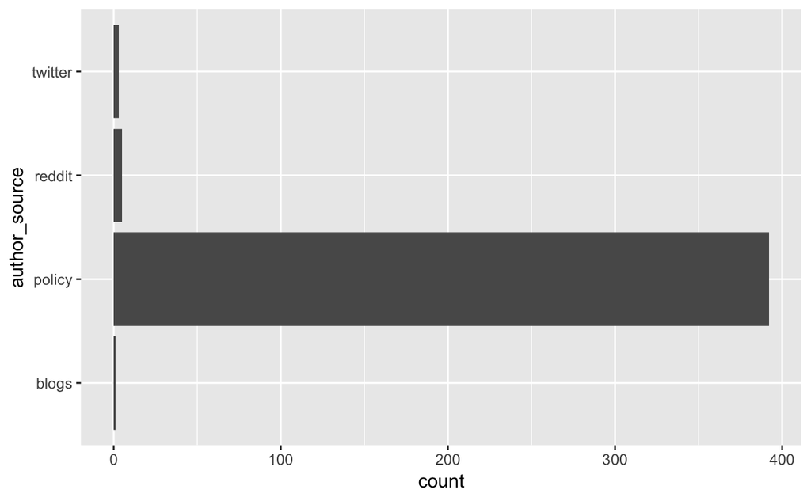

```r
ggplot(data = filter(authors, is.na(author_name))) +
  geom_bar(mapping = aes(x = author_source)) +
  coord_flip()
```

### author_source

**Data type: character**

The name of the source from which this Author’s Mentions were found. This information can also be found in the Mentions set so it’s a bit redundant here, though it means you can look for which sources all the Authors come from without having to join to Mentions and group by author:

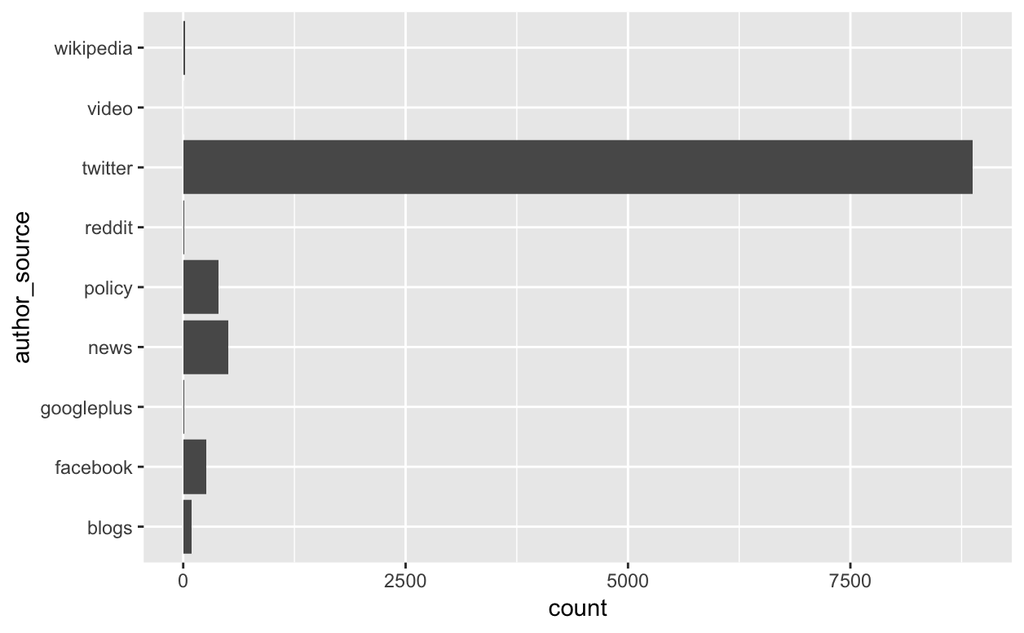

```r
ggplot(data = authors) +
  geom_bar(mapping = aes(x = author_source)) +
  coord_flip()
```

### author_url

**Data type: character**

Any URL that Altmetric have seen fit to attach to an author. These are used by Altmetric to identify blog, news, and Wikipedia Authors, e.g.:

```r
select(
  filter(authors, author_source == "wikipedia"),
  author_name,
  author_url
)
```

```
# A tibble: 20 x 2
   author_name      author_url
   <chr>            <chr>
 1 BullRangifer     http://en.wikipedia.org/wiki/User:BullRangifer
 2 Bobamnertiopsis  http://en.wikipedia.org/wiki/User:Bobamnertiopsis
 3 Rjwilmsi         http://en.wikipedia.org/wiki/User:Rjwilmsi
 4 Imanrahul        http://en.wikipedia.org/wiki/User:Imanrahul
 5 Jeremy112233     http://en.wikipedia.org/wiki/User:Jeremy112233
 6 Chris Capoccia   http://en.wikipedia.org/wiki/User:Chris Capoccia
 7 12.229.155.21    http://en.wikipedia.org/wiki/Special:Contributions/12.229.155.21
 8 Snooganssnoogans http://en.wikipedia.org/wiki/User:Snooganssnoogans
 9 93.44.108.184    http://en.wikipedia.org/wiki/Special:Contributions/93.44.108.184
10 Doc James        http://en.wikipedia.org/wiki/User:Doc James
11 David.Throop     http://en.wikipedia.org/wiki/User:David.Throop
12 Thumperward      http://en.wikipedia.org/wiki/User:Thumperward
13 RDBrown          http://en.wikipedia.org/wiki/User:RDBrown
14 7mike5000        http://en.wikipedia.org/wiki/User:7mike5000
15 Cannondale0702   http://en.wikipedia.org/wiki/User:Cannondale0702
16 Rathfelder       http://en.wikipedia.org/wiki/User:Rathfelder
17 IPFeditor        http://en.wikipedia.org/wiki/User:IPFeditor
18 Basie            http://en.wikipedia.org/wiki/User:Basie
19 AlexanderSilver  http://en.wikipedia.org/wiki/User:AlexanderSilver
20 Lsj              http://sv.wikipedia.org/wiki/User:Lsj
```